[figure not shown]

ME(STI)-2

General Description

MECHANICAL

1. General Description

A: SPECIFICATION

Engine

Model 2.5 L

Cylinder arrangement

Horizontally opposed, liquid cooled, 4-cylinder,

4-stroke gasoline engine

Valve system mechanism

Belt driven, double overhead camshaft,

4-valve/cylinder

Bore × Stroke mm (in) 99.5 × 79.0 (3.92 × 3.11)

Displacement cm

3

(cu in) 2,457 (149.94)

Compression ratio 8.2

Compression pressure

(at 200 — 300 rpm)

kPa (kg/cm

2

, psi) Standard 981 — 1,177 (10 — 12, 142 — 171)

Number of piston rings Pressure ring: 2, Oil ring: 1

Intake valve timing

Open

Max. retard ATDC 5°

Min.

advance

BTDC 25°

Close

Max. retard ABDC 65°

Min.

advance

ABDC 35°

Exhaust valve timing

Open

Max. retard BBDC 32°

Min.

advance

BBDC 72°

Close

Max. retard ATDC 28°

Min.

advance

BTDC 12°

Valve clearance mm (in)

Inspection

value

Intake 0.20

+0.04

–0.06

(0.0079

+0.0016

–0.0024

)

Exhaust 0.35±0.05 (0.0138±0.0020)

Adjustment

value

Intake 0.20

+0.01

–0.03

(0.0079

+0.0004

–0.0012

)

Exhaust 0.35±0.02 (0.0138±0.0008)

Idle speed (Gear shift lever is

in neutral)

rpm

No

load

Standard 700±100

A/C

ON

Standard 750±100

Ignition order 1 → 3 → 2 → 4

Ignition timing BTDC/rpm Standard 15°±10°/700

[figure not shown]

ME(STI)-3

General Description

MECHANICAL

NOTE:

OS: Oversize US: Undersize

Belt tension

adjuster

Adjuster rod protrusion amount mm (in) 5.2 — 6.2 (0.205 — 0.244)

Camshaft

Bending limit mm (in) 0.020 (0.00079)

Cam lobe height mm (in)

Intake Standard 46.55 — 46.65 (1.833 — 1.837)

Exhaust Standard 46.75 — 46.85 (1.841 — 1.844)

Cam base circle diameter mm (in) Standard 37.0 (1.457)

Journal O.D. mm (in)

Front Standard 37.946 — 37.963 (1.4939 — 1.4946)

Center, rear Standard 29.946 — 29.963 (1.1790 — 1.1796)

Oil clearance mm (in) Standard 0.037 — 0.072 (0.0015 — 0.0028)

Thrust clearance mm (in) Standard 0.068 — 0.116 (0.0027 — 0.0047)

Cylinder

head

Warping limit

(Mating surface with cylinder block)

mm (in) 0.035 (0.0014)

Grinding limit mm (in) 0.3 (0.012)

Standard height mm (in) 127.5 (5.02)

Valve seat

Seating angle between valve and valve seat 90°

Contacting width

between valve and

valve seat

mm (in)

Intake Standard 0.6 — 1.4 (0.024 — 0.055)

Exhaust Standard 1.2 — 1.8 (0.047 — 0.071)

Valve guide

Clearance between

the valve guide and

valve stem

mm (in)

Intake Standard 0.030 — 0.057 (0.0012 — 0.0022)

Exhaust Standard 0.040 — 0.067 (0.0016 — 0.0026)

Inside diameter mm (in) 6.000 — 6.012 (0.2362 — 0.2367)

Valve stem outer diameters mm (in)

Intake 5.955 — 5.970 (0.2344 — 0.2350)

Exhaust 5.945 — 5.960 (0.2341 — 0.2346)

Valve guide protrusion amount mm (in) 15.8 — 16.2 (0.622 — 0.638)

Valve

Head edge thickness mm (in)

Intake Standard 1.0 — 1.4 (0.039 — 0.055)

Exhaust Standard 1.3 — 1.7 (0.051 — 0.067)

Overall length mm (in)

Intake 104.4 (4.110)

Exhaust 104.65 (4.1201)

Valve spring

Free length mm (in) 53.48 (2.106)

Tension/spring height N (kgf, lb)/mm (in)

Set

204.6 — 235.4

(20.86 — 24.00, 46.00 — 52.93)/36.0 (1.417)

Lift

363.5 — 401.7

(37.07 — 40.96, 81.73 — 90.32)/26.7 (1.051)

Squareness 2.5°, 2.3 mm (0.091 in) or less

Valve lifter

Outer diameter mm (in) Standard 34.959 — 34.975 (1.3763 — 1.3770)

Valve lifter mating surface inner diameter mm (in) Standard 34.994 — 35.016 (1.3777 — 1.3786)

Valve lifter and valve lifter mating surface

clearance

mm (in) Standard 0.019 — 0.057 (0.0007 — 0.0022)

Cylinder

block

Warping limit

(Mating surface with cylinder head)

mm (in) 0.025 (0.00098)

Grinding limit mm (in) 0.1 (0.004)

Standard height mm (in) 201.0 (7.91)

Cylindricality mm (in) Limit 0.015 (0.0006)

Out-of-roundness mm (in) Limit 0.010 (0.0004)

Clearance between cylinder and piston at

20°C (68°F)

mm (in) Standard –0.010 — 0.010 (–0.00039 — 0.00039)

Cylinder inner diameter boring limit (diameter) mm (in) To 100.005 (3.9372)

[figure not shown]

ME(STI)-4

General Description

MECHANICAL

Piston

Piston grade point mm (in) 38.2 (1.50)

Outer diameter mm (in)

Standard

A 99.505 — 99.515 (3.9175 — 3.9179)

B 99.495 — 99.505 (3.9171 — 3.9175)

0.25 (0.0098) OS 99.745 — 99.765 (3.9270 — 3.9278)

0.50 (0.0197) OS 99.995 — 100.015 (3.9368 — 3.9376)

Piston pin

Degree of fit

Piston pin must be fitted into position with

thumb at 20°C (68°F).

Clearance between piston pin hole and pis-

ton pin

mm (in) Standard 0.004 — 0.008 (0.0002 — 0.0003)

Piston ring

Piston ring gap mm (in)

Top ring Standard 0.23 — 0.28 (0.0091 — 0.0110)

Second ring Standard 0.37 — 0.52 (0.015 — 0.0205)

Oil ring Standard 0.20 — 0.50 (0.0079 — 0.0197)

Clearance between

piston ring and piston

ring groove

mm (in)

Top ring Standard 0.040 — 0.080 (0.0016 — 0.0031)

Second ring Standard 0.030 — 0.070 (0.0012 — 0.0028)

Connecting

rod and

connecting

rod bearing

Bend or twist per 100 mm (3.94 in) in

length

mm (in) Limit 0.10 (0.0039)

Thrust clearance mm (in) Standard 0.070 — 0.330 (0.0028 — 0.0130)

Oil clearance mm (in) Standard 0.017 — 0.045 (0.0007 — 0.0018)

Bearing size

(Thickness at center)

mm (in)

Standard 1.490 — 1.506 (0.0587 — 0.0593)

0.03 (0.0012) US 1.504 — 1.512 (0.0592 — 0.0595)

0.05 (0.0020) US 1.514 — 1.522 (0.0596 — 0.0599)

0.25 (0.0098) US 1.614 — 1.622 (0.0635 — 0.0639)

Bushing of

small end

Clearance between piston pin and bushing mm (in) Standard 0 — 0.022 (0 — 0.0009)

Crankshaft

and crank-

shaft bear-

ing

Bending limit mm (in) 0.035 (0.0014)

Crank pin

Cylindricality mm (in) Limit 0.006 (0.0002)

Out-of-roundness mm (in) Limit 0.005 (0.0002)

Grinding limit (dia.) mm (in) To 51.734 (2.0368)

Crank journal

Cylindricality mm (in) Limit 0.006 (0.0002)

Out-of-roundness mm (in) Limit 0.005 (0.0002)

Grinding limit (dia.) mm (in) To 59.742 (2.3520)

Crank pin outer diameter mm (in)

Standard 51.976 — 52.000 (2.0463 — 2.0472)

0.03 (0.0012) US 51.954 — 51.970 (2.0454 — 2.0461)

0.05 (0.0020) US 51.934 — 51.950 (2.0447 — 2.0453)

0.25 (0.0098) US 51.734 — 51.750 (2.0368 — 2.0374)

Crank journal outer diameter mm (in)

Standard 59.984 — 60.008 (2.3616 — 2.3625)

0.03 (0.0012) US 59.962 — 59.978 (2.3607 — 2.3613)

0.05 (0.0020) US 59.942 — 59.958 (2.3599 — 2.3605)

0.25 (0.0098) US 59.742 — 59.758 (2.3520 — 2.3527)

Bearing size

(Thickness at center)

mm (in)

#1, #3

Standard 1.998 — 2.015 (0.0787 — 0.0793)

0.03 (0.0012) US 2.017 — 2.020 (0.0794 — 0.0795)

0.05 (0.0020) US 2.027 — 2.030 (0.0798 — 0.0799)

0.25 (0.0098) US 2.127 — 2.130 (0.0837 — 0.0839)

#2, #4,

#5

Standard 2.000 — 2.017 (0.0787 — 0.0794)

0.03 (0.0012) US 2.019 — 2.022 (0.0795 — 0.0796)

0.05 (0.0020) US 2.029 — 2.032 (0.0799 — 0.0800)

0.25 (0.0098) US 2.129 — 2.132 (0.0838 — 0.0839)

Thrust clearance mm (in) Standard 0.030 — 0.115 (0.0012 — 0.0045)

Oil clearance mm (in) Standard 0.010 — 0.030 (0.00039 — 0.0012)

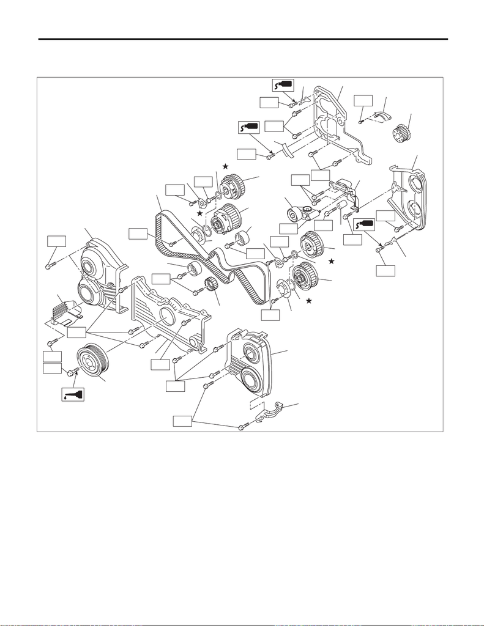

ME(STI)-5

General Description

MECHANICAL

B: COMPONENT

1. TIMING BELT

ME-08034

(7)

(6)

(10)

(5)

(23)

(11)

(15)

(25)

(17)

(9)

(13)

(14)

(12)

(16)

(8)

(19)

(19)

(19)

(19)

(21)

(22)

(22)

(21)

(2)

(3)

(4)

(1)

(20)

(20)

(20)

T3

T4

T2

T2

T2

T2

T2

T1

T7

T1

T7

T7

T8

T1

T3

T8

T3

T2

T2

T6

T2

T5

T2

(18)

T9

(24)

T2

[figure not shown]

ME(STI)-6

General Description

MECHANICAL

(1) Timing belt cover No. 2 RH (14) Belt idler Tightening torque: N·m (kgf-m, ft-lb)

(2) Timing belt guide (15) Timing belt cover LH T1: 3.4 (0.3, 2.5)

(3) Crank sprocket (16) Front belt cover T2: 5 (0.5, 3.7)

(4) Timing belt cover No. 2 LH (17) Timing belt cover RH T3: 6.4 (0.7, 4.7)

(5) Tensioner bracket (18) Crank pulley T4: 9.75 (1.0, 7.2)

(6) Automatic belt tension adjuster

ASSY

(19) O-ring T5: 24.5 (2.5, 18.1)

(7) Belt idler (20) Timing belt guide T6: 25 (2.5, 18.4)

(8) Exhaust cam sprocket RH (21) Intake actuator cover T7: 39 (4.0, 28.8)

(9) Intake cam sprocket RH (22) Exhaust actuator cover T8: <Ref. to ME(STI)-60, INSTALLA-

TION, Cam Sprocket.>

(10) Intake cam sprocket LH (23) Belt idler T9: <Ref. to ME(STI)-48, INSTALLA-

TION, Crank Pulley.>

(11) Exhaust cam sprocket LH (24) Engine harness cover

(12) Timing belt (25) Engine harness stay

(13) Belt idler No. 2

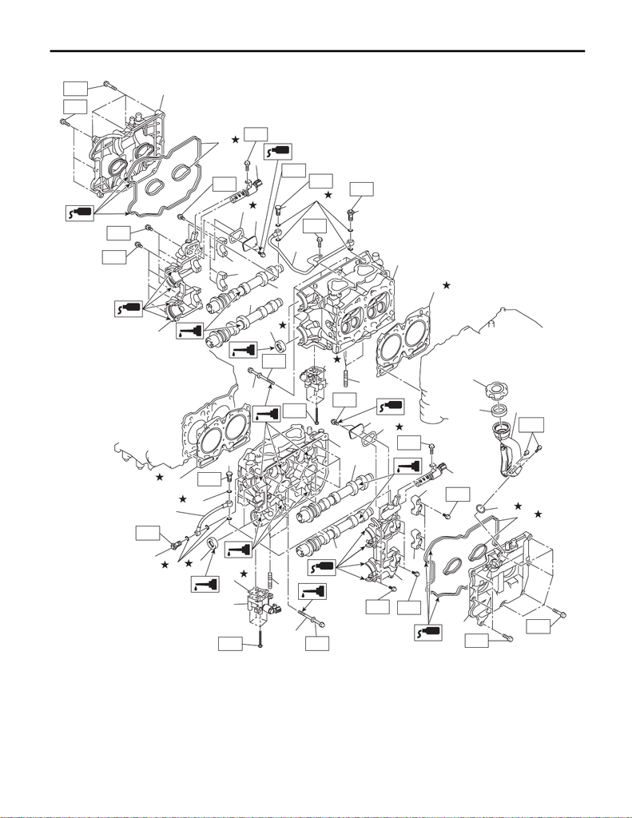

ME(STI)-7

General Description

MECHANICAL

2. CYLINDER HEAD AND CAMSHAFT

ME-04944

T6

T6

T6

T6

T6

T6

T5

(3)

(7)

(6)

(9)

(8)

(10)

(12)

(13)

(25)

(21)

(20)

(6)

(16)

(17)

(18)

(9)

(8)

(19)

(15)

(14)

(29)

(11)

(5)

(4)

(22)

T6

T6

(14)

(29)

(35)

(12)

(27)

(26)

(27)

(33)

(32)

T1

T5

(11)

(31)

(30)

T4

T2

T1

T4

T3

T3

(36)

(24)

(23)

T1

(34)

T6

(1)

(2)

T6

(28)

T2

(33)

(27)

T1

T4

(32)

T4

[figure not shown]

ME(STI)-8

General Description

MECHANICAL

(1) Rocker cover RH (16) Intake camshaft LH (31) Gasket RH

(2) Rocker cover gasket RH (17) Exhaust camshaft LH (32) Union bolt with filter (with protru-

sion)

(3) Front camshaft cap RH (18) Front camshaft cap LH (33) Union bolt without filter (without

protrusion)

(4) Intake camshaft cap RH (19) Intake camshaft cap LH (34) Gasket

(5) Intake camshaft RH (20) Exhaust camshaft cap LH (35) Exhaust oil flow control solenoid

valve LH

(6) Intake oil flow control solenoid

valve

(21) Rocker cover gasket LH (36) Gasket LH

(7) Exhaust camshaft cap RH (22) Rocker cover LH

(8) Gasket (23) Oil filler cap Tightening torque: N·m (kgf-m, ft-lb)

(9) Oil return cover (24) Oil filler duct T1: 6.4 (0.7, 4.7)

(10) Exhaust camshaft RH (25) O-ring T2: 9 (0.9, 6.6)

(11) Cylinder head bolt (26) Oil pipe LH T3: 10 (1.0, 7.4)

(12) Oil seal (27) Gasket T4: 29 (3.0, 21.4)

(13) Cylinder head RH (28) Oil pipe RH T5: <Ref. to ME(STI)-70, INSTALLA-

TION, Cylinder Head.>

(14) Cylinder head gasket (29) Stud bolt T6: <Ref. to ME(STI)-64, INSTALLA-

TION, Camshaft.>

(15) Cylinder head LH (30) Exhaust oil flow control solenoid

valve RH

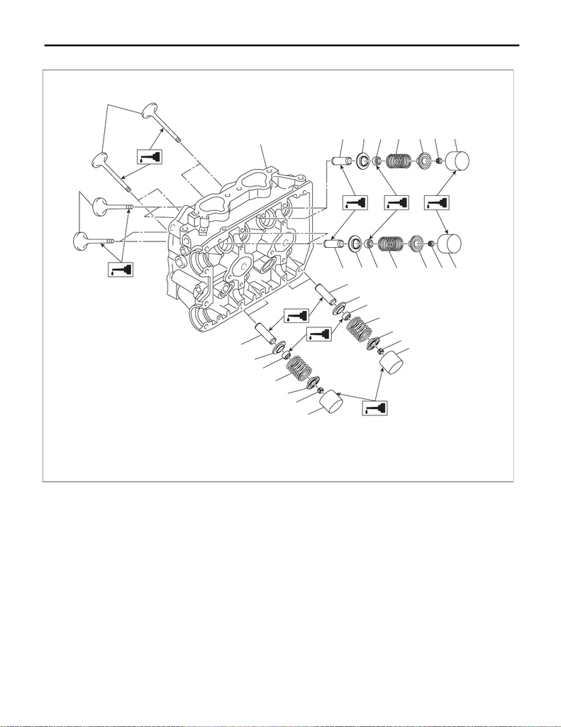

ME(STI)-9

General Description

MECHANICAL

3. CYLINDER HEAD AND VALVE ASSEMBLY

(1) Exhaust valve (5) Intake valve oil seal (9) Valve lifter

(2) Intake valve (6) Valve spring (10) Exhaust valve oil seal

(3) Cylinder head (7) Valve spring retainer (11) Intake valve guide

(4) Valve spring seat (8) Valve spring retainer key (12) Exhaust valve guide

(3)

(1)

(12)

(10)

(4)

(6)

(7)

(8)

(9)

(10)

(4)

(6)

(7)

(8)

(9)

ME-04990

(12)

(2)

(11)

(4)

(5)

(6)

(7)

(8)

(9)

(11)

(4)

(5)

(6)

(7)

(8)

(9)

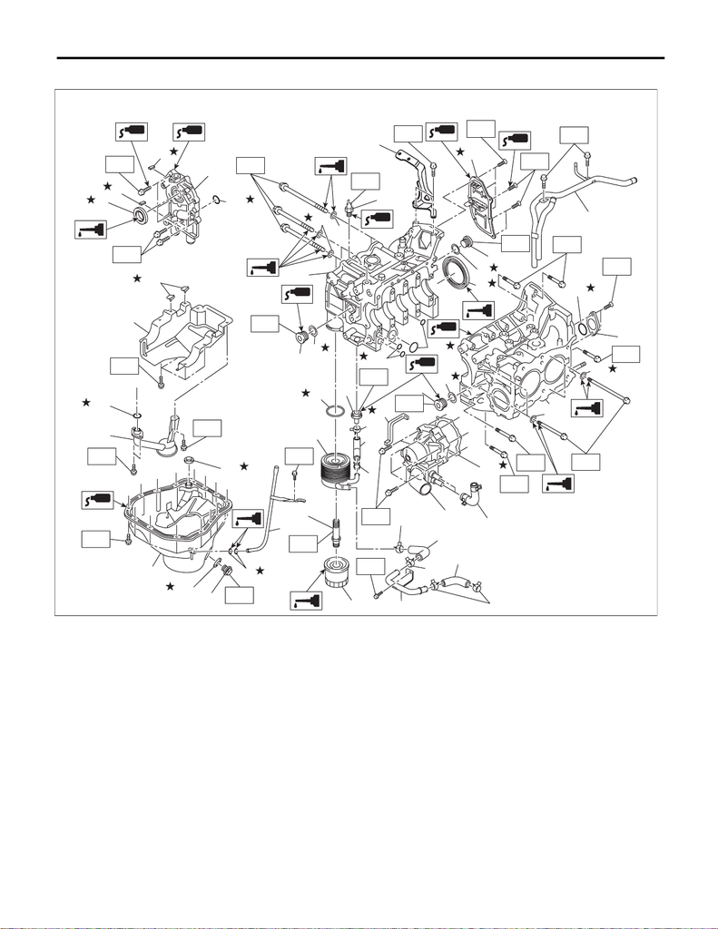

ME(STI)-10

General Description

MECHANICAL

4. CYLINDER BLOCK

(39)

(32)

T8

(17)

(24)

(15)

(27)

T9

ME-05987

T4

T2

T2

T11

T6

T11

T6

T2

T10

T10

(9)

(10)

(10)

(11)

(13)

(25)

(26)

(4)

(4)

(4)

(3)

(3)

(3)

(2)

(5)

(10)

T6

T2

(14)

(28)

T3

(18)

(10)

T2

(29)

(31)

T1

T7

(19)

(20)

(21)

(22)

(30)

(29)

(30)

(12)

(35)

T2

(6)

T2

(10)

T2

(8)

(7)

(34)

(34)

T2

T2

(23)

T10

T6

(1)

T5

(33)

(16)

T2

(39)

(36)

(39)

(38)

(37)

(39)

(39)

[figure not shown]

ME(STI)-11

General Description

MECHANICAL

(1) Oil pressure switch (19) Gasket (37) Oil cooler hose B

(2) Cylinder block RH (20) Oil pan (38) Oil cooler hose C

(3) Service hole plug (21) Drain plug (39) Clip

(4) Gasket (22) Drain plug gasket

(5) Oil separator cover (23) Oil level gauge guide Tightening torque: N·m (kgf-m, ft-lb)

(6) Water by-pass pipe (24) Oil filter T1: 5 (0.5, 3.7)

(7) Oil pump (25) Gasket T2: 6.4 (0.7, 4.7)

(8) Front oil seal (26) Water pump hose T3: 10 (1.0, 7.4)

(9) Rear oil seal (27) Nipple T4: First 12 (1.2, 8.9)

(10) O-ring (28) Seal Second 12 (1.2, 8.9)

(11) Service hole cover (29) Washer T5: 16 (1.6, 11.8)

(12) Cylinder block LH (30) Seal washer T6: 25 (2.5, 18.4)

(13) Water pump (31) O-ring T7: 46.5 (4.7, 34.3)

(14) Baffle plate (32) Gasket T8: 54 (5.5, 39.8)

(15) Oil cooler (33) Intercooler stay RH No. 2 (engine

rear hanger)

T9: 69 (7.0, 50.9)

(16) Oil cooler pipe (34) Oil pump seal T10: 70 (7.1, 51.6)

(17) Connector (35) Water pump sealing T11: <Ref. to ME(STI)-84, INSTAL-

LATION, Cylinder Block.>

(18) Oil strainer (36) Oil cooler hose A

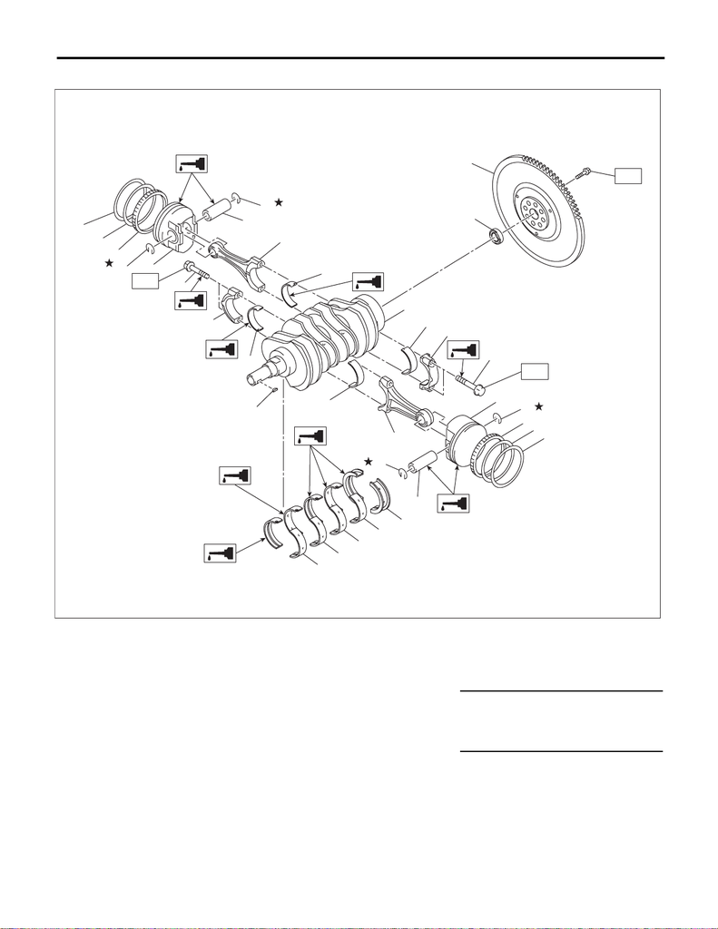

ME(STI)-12

General Description

MECHANICAL

5. CRANKSHAFT AND PISTON

(1) Flywheel (8) Snap ring (15) Crankshaft bearing #1, #3

(2) Ball bearing (9) Connecting rod bolt (16) Crankshaft bearing #2, #4

(3) Top ring (10) Connecting rod (17) Crankshaft bearing #5

(4) Second ring (11) Connecting rod bearing

(5) Oil ring (12) Connecting rod cap Tightening torque: N·m (kgf-m, ft-lb)

(6) Piston (13) Crankshaft T1: 52 (5.3, 38.4)

(7) Piston pin (14) Woodruff key T2: <Ref. to CL-15, INSTALLATION,

Flywheel.>

ME-05051

T1

T1

(15)

(16)

(15)

(16)

(17)

(8)

(7)

(3)

(4)

(5)

(8)

(6)

(9)

(12)

(11)

(13)

(11)

(10)

(3)

(4)

(5)

(8)

(6)

(7)

(8)

(9)

(10)

(12)

(11)

(11)

(14)

(1)

(2)

T2

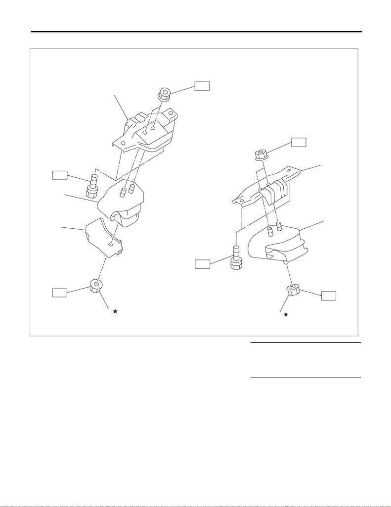

ME(STI)-13

General Description

MECHANICAL

6. ENGINE MOUNTING

(1) Heat shield cover (3) Front engine mounting bracket Tightening torque: N·m (kgf-m, ft-lb)

(2) Front cushion rubber (4) Nut T1: 35 (3.6, 25.8)

T2: 42 (4.3, 31.0)

T3: 60 (6.1, 44.3)

(3)

T3

T1

(2)

(1)

(3)

(2)

T3

T1

T2

T2

(4)

(4)

ME-08036

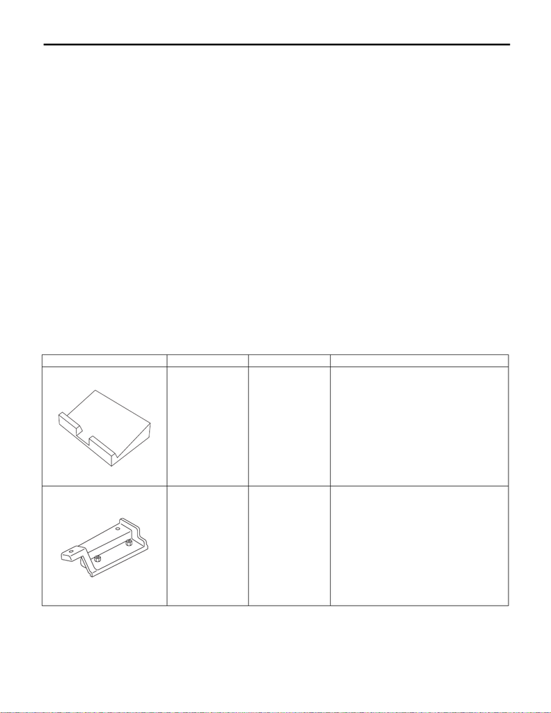

ME(STI)-14

General Description

MECHANICAL

C: CAUTION

• Prior to starting work, pay special attention to the following:

1. Always wear work clothes, a work cap, and protective shoes. Additionally, wear a helmet, protective

goggles, etc. if necessary.

2. Protect the vehicle using a seat cover, fender cover, etc.

3. Prepare the service tools, clean cloth, containers to catch grease and oil, etc.

• Vehicle components are extremely hot immediately after driving. Be wary of receiving burns from heated

parts.

• When performing a repair, identify the cause of trouble and avoid unnecessary removal, disassembly and

replacement.

• Before disconnecting connectors of sensors or units, be sure to disconnect the ground cable from battery.

• Always use the jack-up point when the shop jacks or rigid racks are used to support the vehicle.

• Remove or install the engine in an area where chain hoists, lifting devices, etc. are available for ready use.

When lifting up the vehicle, make sure to support the vehicle at the jack-up points.

• Be careful not to let any oil or grease contact the clutch disc, flywheel or timing belt.

• Remove contamination including dirt and corrosion before removal, installation, disassembly or assembly.

• Keep the removed parts in order and protect them from dust and dirt.

• All removed parts, if to be reused, should be reinstalled in the original positions with attention to the correct

directions, etc.

• Rotating parts and sliding parts such as piston, bearing and gear should be coated with oil when being as-

sembled.

• Bolts, nuts and washers should be replaced with new parts as required.

• Be sure to tighten the fasteners including bolts and nuts to the specified torque.

D: PREPARATION TOOL

1. SPECIAL TOOL

ILLUSTRATION TOOL NUMBER DESCRIPTION REMARKS

498267600 CYLINDER HEAD

TABLE

• Used for replacing valve guides.

• Used for removing and installing valve spring.

498457000 ENGINE STAND

ADAPTER RH

Used together with ENGINE STAND

(499817100).

ST-498267600

ST-498457000

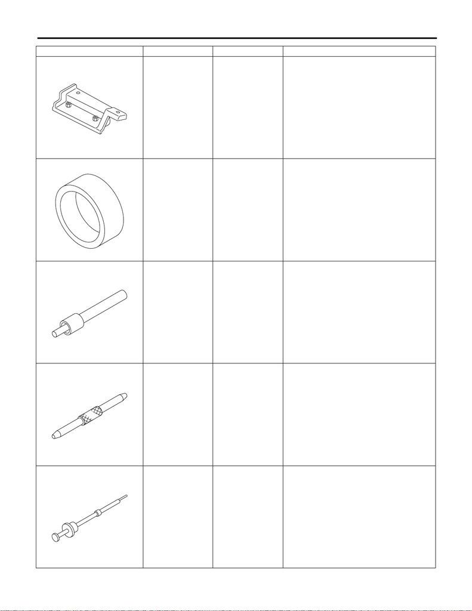

ME(STI)-15

General Description

MECHANICAL

498457100 ENGINE STAND

ADAPTER LH

Used together with ENGINE STAND

(499817100).

498747300 PISTON GUIDE Used for installing the piston into the cylinder.

498857100 VALVE OIL SEAL

GUIDE

Used for press-fitting of intake valve guide oil

seals and exhaust valve guide oil seals.

499017100 PISTON PIN GUIDE Used for installing piston pin, piston and con-

necting rod.

499097700 PISTON PIN

REMOVER ASSY

Used for removing piston pin.

ILLUSTRATION TOOL NUMBER DESCRIPTION REMARKS

ST-498457100

ST-498747300

ST-498857100

ST-499017100

ST-499097700

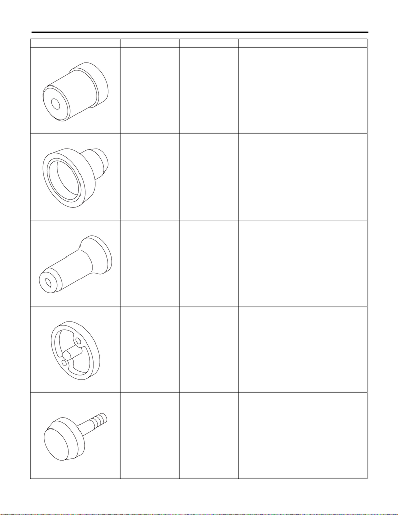

ME(STI)-16

General Description

MECHANICAL

499587100 OIL SEAL

INSTALLER

Used for installing oil pump oil seal.

499587200 CRANKSHAFT OIL

SEAL INSTALLER

• Used for installing crankshaft oil seal.

• Used together with CRANKSHAFT OIL SEAL

GUIDE (499597100).

499587600 OIL SEAL

INSTALLER

Used for installing the camshaft oil seal.

499597100 CRANKSHAFT OIL

SEAL GUIDE

• Used for installing crankshaft oil seal.

• Used together with CRANKSHAFT OIL SEAL

INSTALLER (499587200).

499597200 OIL SEAL GUIDE • Used for installing the camshaft oil seal.

• Used together with OIL SEAL INSTALLER

(499587600).

ILLUSTRATION TOOL NUMBER DESCRIPTION REMARKS

ST-499587100

ST-499587200

ST-499587600

ST-499597100

ST-499597200

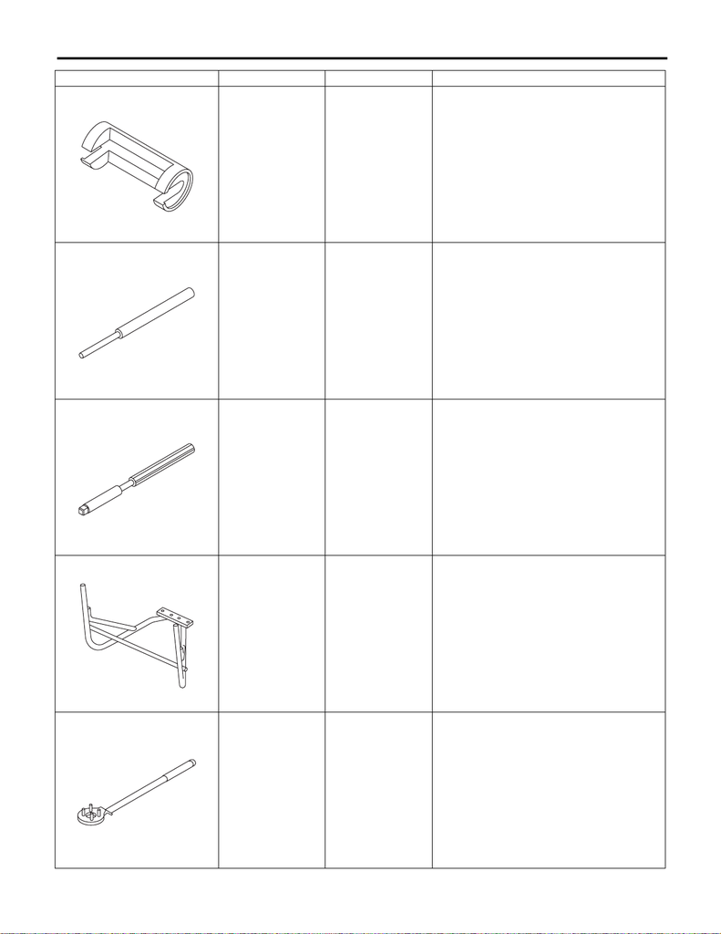

ME(STI)-17

General Description

MECHANICAL

499718000 VALVE SPRING

REMOVER

Used for removing and installing valve spring.

499767200 VALVE GUIDE

REMOVER

Used for removing valve guides.

499767400 VALVE GUIDE

REAMER

Used for reaming valve guides.

499817100 ENGINE STAND • Used for disassembling and assembling

engine.

• Used together with ENGINE STAND

ADAPTER RH (498457000) & LH (498457100).

499977100 CRANK PULLEY

WRENCH

Used for removing and installing the crank pul-

ley.

ILLUSTRATION TOOL NUMBER DESCRIPTION REMARKS

ST-499718000

ST-499767200

ST-499767400

ST-499817100

ST-499977100

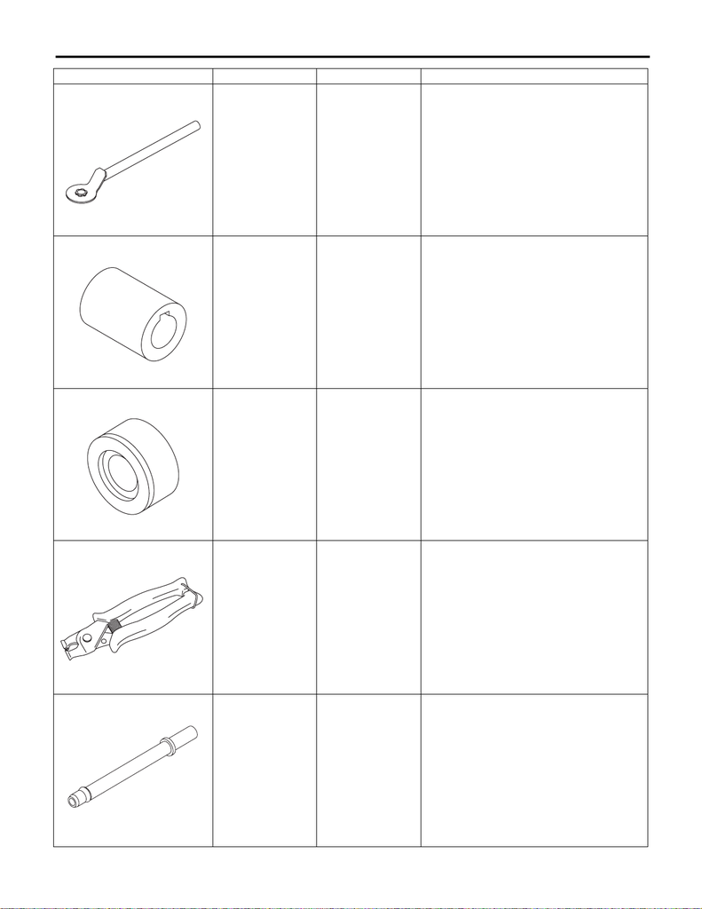

ME(STI)-18

General Description

MECHANICAL

499977500 CAM SPROCKET

WRENCH

Used for removing and installing intake cam

sprocket and exhaust cam sprocket.

499987500 CRANKSHAFT

SOCKET

Used for rotating crankshaft.

18251AA020 VALVE GUIDE

ADJUSTER

Used for installing intake valve guides and

exhaust valve guides.

18353AA000 CLAMP PLIERS • Used for removing and installing the PCV

hose.

• This tool is made by the French company

CAILLAU. (code) 54.0.000.205

To make it easier to obtain, it has been provided

with a tool number.

18471AA000 FUEL PIPE

ADAPTER

Used for inspecting the fuel pressure.

ILLUSTRATION TOOL NUMBER DESCRIPTION REMARKS

ST-499977500

ST-499987500

ST18251AA020

ST18353AA000

ST18471AA000

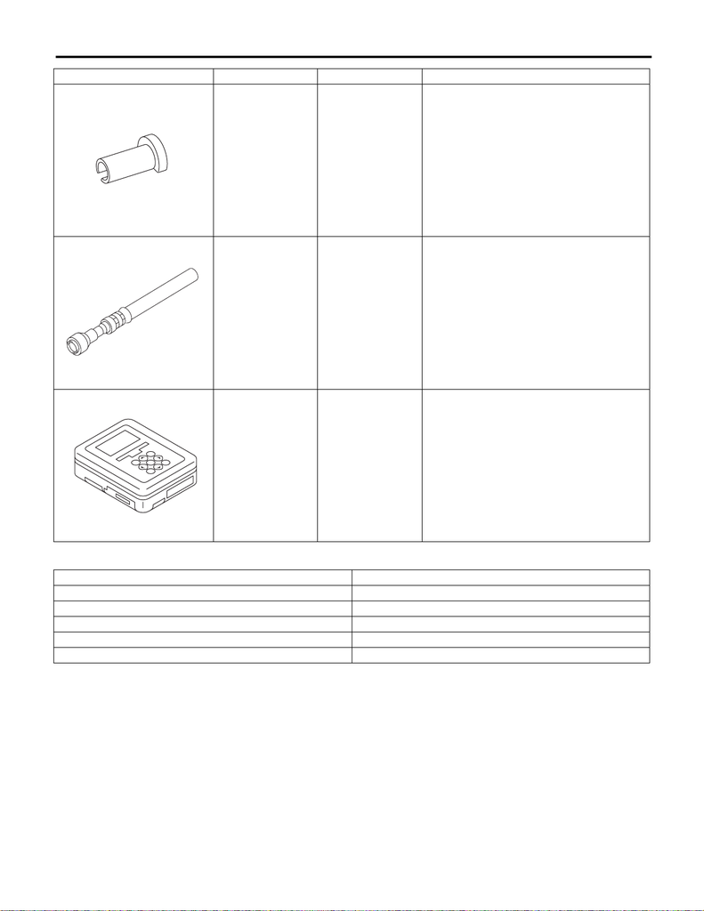

ME(STI)-19

General Description

MECHANICAL

2. GENERAL TOOL

42099AE000 QUICK CONNEC-

TOR RELEASE

Used for removing the quick connector.

42075AG690 FUEL HOSE Used for inspecting the fuel pressure.

NOTE:

This is the SUBARU genuine part.

1B022XU0 SUBARU SELECT

MONITOR III KIT

Used for various inspections.

TOOL NAME REMARKS

Compression gauge Used for measuring compression.

Timing light Used for measuring ignition timing.

Vacuum gauge Used for measuring intake manifold vacuum.

Oil pressure gauge Used for measuring engine oil pressure.

Fuel pressure gauge Used for measuring fuel pressure.

ILLUSTRATION TOOL NUMBER DESCRIPTION REMARKS

ST42099AE000

ST42075AG690

ST1B022XU0